# `Project 6 - Unsupervised Learning`

# **Correlation**

```python
data.corr() # with this function will try to see a correlation between variables numerically
# it is hard to see any correlation in numbers so i will try graphycally
```

|  | CreditScore | Age | Tenure | Balance | NumOfProducts | HasCrCard | IsActiveMember | EstimatedSalary | Exited | Geography_France | Geography_Germany | Geography_Spain | Gender_Female | Gender_Male |
| --- | --- | --- | --- | --- | --- | --- | --- | --- | --- | --- | --- | --- | --- | --- |
| CreditScore | 1.000000 | -0.003965 | 0.000842 | 0.006268 | 0.012238 | -0.005458 | 0.025651 | -0.001384 | -0.027094 | -0.008928 | 0.005538 | 0.004780 | 0.002857 | -0.002857 |
| Age | -0.003965 | 1.000000 | -0.009997 | 0.028308 | -0.030680 | -0.011721 | 0.085472 | -0.007201 | 0.285323 | -0.039208 | 0.046897 | -0.001685 | 0.027544 | -0.027544 |
| Tenure | 0.000842 | -0.009997 | 1.000000 | -0.012254 | 0.013444 | 0.022583 | -0.028362 | 0.007784 | -0.014001 | -0.002848 | -0.000567 | 0.003868 | -0.014733 | 0.014733 |
| Balance | 0.006268 | 0.028308 | -0.012254 | 1.000000 | -0.304180 | -0.014858 | -0.010084 | 0.012797 | 0.118533 | -0.231329 | 0.401110 | -0.134892 | -0.012087 | 0.012087 |
| NumOfProducts | 0.012238 | -0.030680 | 0.013444 | -0.304180 | 1.000000 | 0.003183 | 0.009612 | 0.014204 | -0.047820 | 0.001230 | -0.010419 | 0.009039 | 0.021859 | -0.021859 |
| HasCrCard | -0.005458 | -0.011721 | 0.022583 | -0.014858 | 0.003183 | 1.000000 | -0.011866 | -0.009933 | -0.007138 | 0.002467 | 0.010577 | -0.013480 | -0.005766 | 0.005766 |
| IsActiveMember | 0.025651 | 0.085472 | -0.028362 | -0.010084 | 0.009612 | -0.011866 | 1.000000 | -0.011421 | -0.156128 | 0.003317 | -0.020486 | 0.016732 | -0.022544 | 0.022544 |
| EstimatedSalary | -0.001384 | -0.007201 | 0.007784 | 0.012797 | 0.014204 | -0.009933 | -0.011421 | 1.000000 | 0.012097 | -0.003332 | 0.010297 | -0.006482 | 0.008112 | -0.008112 |
| Exited | -0.027094 | 0.285323 | -0.014001 | 0.118533 | -0.047820 | -0.007138 | -0.156128 | 0.012097 | 1.000000 | -0.104955 | 0.173488 | -0.052667 | 0.106512 | -0.106512 |
| Geography_France | -0.008928 | -0.039208 | -0.002848 | -0.231329 | 0.001230 | 0.002467 | 0.003317 | -0.003332 | -0.104955 | 1.000000 | -0.580359 | -0.575418 | -0.006772 | 0.006772 |
| Geography_Germany | 0.005538 | 0.046897 | -0.000567 | 0.401110 | -0.010419 | 0.010577 | -0.020486 | 0.010297 | 0.173488 | -0.580359 | 1.000000 | -0.332084 | 0.024628 | -0.024628 |
| Geography_Spain | 0.004780 | -0.001685 | 0.003868 | -0.134892 | 0.009039 | -0.013480 | 0.016732 | -0.006482 | -0.052667 | -0.575418 | -0.332084 | 1.000000 | -0.016889 | 0.016889 |
| Gender_Female | 0.002857 | 0.027544 | -0.014733 | -0.012087 | 0.021859 | -0.005766 | -0.022544 | 0.008112 | 0.106512 | -0.006772 | 0.024628 | -0.016889 | 1.000000 | -1.000000 |
| Gender_Male | -0.002857 | -0.027544 | 0.014733 | 0.012087 | -0.021859 | 0.005766 | 0.022544 | -0.008112 | -0.106512 | 0.006772 | -0.024628 | 0.016889 | -1.000000 | 1.000000 |

# **Pair Plots**

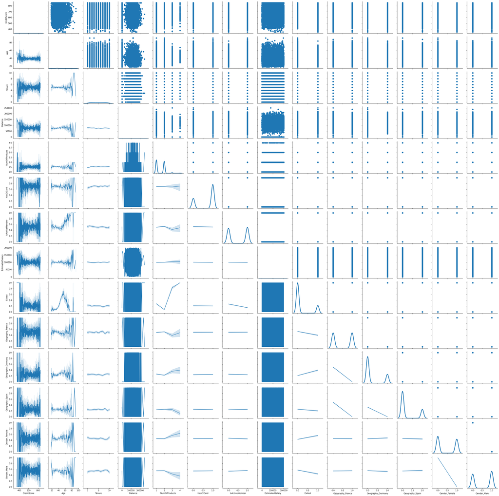

```python
import seaborn as sns

g = sns.PairGrid(data)
g.map_upper(plt.scatter)
g.map_lower(sns.lineplot)
g.map_diag(sns.kdeplot, lw=3, legend=True);
```

# **Heat map**

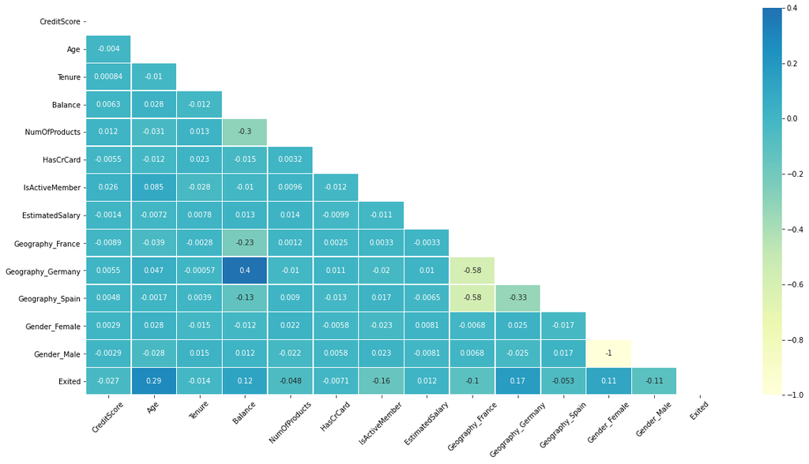

```python
#Another correlation methods
plt.figure(figsize=(20,10))
mask = np.zeros_like(data.corr('spearman'))
mask[np.triu_indices_from(mask)] = True
ax =sns.heatmap(data.corr(),
            annot=True,
            linewidths=.5,
            center=0,
            cmap="YlGnBu",
            mask= mask,
           )
ax.set_xticklabels(ax.get_xticklabels(), rotation=45);
plt.show()
```

### *Additionally, Male and Female have the highest correlation (negative) between all the variables, that is -1.*

### *It will be interesting to see how this imputs that are not showing a good correlation will help to train a model to predict the "exit".*

### *The genders Male and females, have exactly oposite correlation respect to the target 0.11 and -0.11*

### *Ovrall the correlation between variables is low but we found that some variable are oposite lake the gender.*

## 4. Distinguish the feature and target set and divide the data set into training and test sets (5 points)

```python
# Now we will get a list of unique values to evalaute how to arrange the data set
# This is to prepar the data set to split it
for a in list(data.columns):
    n = data[a].unique()

    # if number of unique values is less than 30, print the values. Otherwise print the number of unique values
    if len(n)<30:
        print(a + ': ')
        print(data[a].value_counts(normalize=True))
        print()
    else:
        print(a + ': ' +str(len(n)) + ' unique values')
        print()
```

```
CreditScore: 460 unique values

Age: 70 unique values

Tenure:
2     0.1048
1     0.1035
7     0.1028
8     0.1025
5     0.1012
3     0.1009
4     0.0989
9     0.0984
6     0.0967
10    0.0490
0     0.0413
Name: Tenure, dtype: float64

Balance: 6382 unique values

NumOfProducts:
1    0.5084
2    0.4590
3    0.0266
4    0.0060
Name: NumOfProducts, dtype: float64

HasCrCard:
1    0.7055
0    0.2945
Name: HasCrCard, dtype: float64

IsActiveMember:
1    0.5151
0    0.4849
Name: IsActiveMember, dtype: float64

EstimatedSalary: 9999 unique values

Exited:
```

[output cut: 13 more lines]

```

Geography_Spain:
0    0.7523
1    0.2477
Name: Geography_Spain, dtype: float64

Gender_Female:
0    0.5457
1    0.4543
Name: Gender_Female, dtype: float64

Gender_Male:
1    0.5457
0    0.4543
Name: Gender_Male, dtype: float64
```

```python
# This is to get the list of the column names and arrange the order later on to prepare it for split the data
column_names = list(data.columns.values)
print (list(data.columns.values))
```

```
['CreditScore', 'Age', 'Tenure', 'Balance', 'NumOfProducts', 'HasCrCard', 'IsActiveMember', 'EstimatedSalary', 'Exited', 'Geography_France', 'Geography_Germany', 'Geography_Spain', 'Gender_Female', 'Gender_Male']
```

```python
column_names = ['CreditScore', 'Age', 'Tenure', 'Balance', 'NumOfProducts', 'HasCrCard', 'IsActiveMember', 'EstimatedSalary', 'Geography_France', 'Geography_Germany', 'Geography_Spain', 'Gender_Female', 'Gender_Male', 'Exited']

data = data.reindex(columns=column_names) #to split the data easily
```

### reindex the columns was the easiest way i found to re-arrange the data set.

### Maybe if I split the data set after deleting the columns and before the one-hot code, i would avoid this step.

## **I will try next project.**

```python
data.head() # to check the last arrange before split the data.
```

|  | CreditScore | Age | Tenure | Balance | NumOfProducts | HasCrCard | IsActiveMember | EstimatedSalary | Geography_France | Geography_Germany | Geography_Spain | Gender_Female | Gender_Male | Exited |
| --- | --- | --- | --- | --- | --- | --- | --- | --- | --- | --- | --- | --- | --- | --- |
| 0 | 619 | 42 | 2 | 0.00 | 1 | 1 | 1 | 101348.88 | 1 | 0 | 0 | 1 | 0 | 1 |
| 1 | 608 | 41 | 1 | 83807.86 | 1 | 0 | 1 | 112542.58 | 0 | 0 | 1 | 1 | 0 | 0 |
| 2 | 502 | 42 | 8 | 159660.80 | 3 | 1 | 0 | 113931.57 | 1 | 0 | 0 | 1 | 0 | 1 |
| 3 | 699 | 39 | 1 | 0.00 | 2 | 0 | 0 | 93826.63 | 1 | 0 | 0 | 1 | 0 | 0 |
| 4 | 850 | 43 | 2 | 125510.82 | 1 | 1 | 1 | 79084.10 | 0 | 0 | 1 | 1 | 0 | 0 |

```python
# Specify the data
X_data = data.iloc[:, :-1]
```

```python
X_data.shape
```

```
(10000, 13)
```

```python
X_data.head()
```

|  | CreditScore | Age | Tenure | Balance | NumOfProducts | HasCrCard | IsActiveMember | EstimatedSalary | Geography_France | Geography_Germany | Geography_Spain | Gender_Female | Gender_Male |
| --- | --- | --- | --- | --- | --- | --- | --- | --- | --- | --- | --- | --- | --- |
| 0 | 619 | 42 | 2 | 0.00 | 1 | 1 | 1 | 101348.88 | 1 | 0 | 0 | 1 | 0 |
| 1 | 608 | 41 | 1 | 83807.86 | 1 | 0 | 1 | 112542.58 | 0 | 0 | 1 | 1 | 0 |
| 2 | 502 | 42 | 8 | 159660.80 | 3 | 1 | 0 | 113931.57 | 1 | 0 | 0 | 1 | 0 |
| 3 | 699 | 39 | 1 | 0.00 | 2 | 0 | 0 | 93826.63 | 1 | 0 | 0 | 1 | 0 |
| 4 | 850 | 43 | 2 | 125510.82 | 1 | 1 | 1 | 79084.10 | 0 | 0 | 1 | 1 | 0 |

```python
# Specify the target variable
y_data = data.iloc[:, -1]
```

```python
y_data.shape
```

```
(10000,)
```

```python
# Split the data up in train and test sets, i will use 0.30 for the test as we have been using it along the course.
X_train, X_test, y_train, y_test = train_test_split(X_data, y_data, test_size = 0.30, random_state = 7)
```

## 5. Normalize the train and test data (10points)

```python
X_train = preprocessing.normalize(X_train) # this has to be done after splitting the data

X_test = preprocessing.normalize(X_test) # This is part of the question 7 as well.
```

```python
#Below I want to check the size of the data. This is mainly because i run this code so many times and eveng change the order of som cells,
#so the code below allows me to QC the the next cells.

print(X_train.shape)
print(X_test.shape)
print(y_train.shape)
print(y_test.shape)
```

```
(7000, 13)
(3000, 13)
(7000,)
(3000,)
```

```python
from sklearn.preprocessing import StandardScaler
# Define the scaler , this is done to have the data in the same range of values.
scaler = StandardScaler().fit(X_train)

# Scale the train set
X_train = scaler.transform(X_train)

# Scale the test set
X_test = scaler.transform(X_test)
```

## 5. Initialize & build the model. Identify the points of improvement and implement the same. (20)

# Neural Network Building and Model Training:

### **Some of the comments below is taken from the mentor session, but i want to keep it here for my reference in the future**

Creating a model Keras model object can be created with Sequential class

At the outset, the model is empty per se. It is completed by adding additional layers and compilation

```python
model = Sequential() # Initialize the constructor
```

Adding layers [layers and activations] Keras layers can be added to the model

Adding layers are like stacking lego blocks one by one

It should be noted that as this is a classification problem, sigmoid layer (softmax for multi-class problems) should be added

```python
#I repeated this step so many times trying to find the correct hyperparameter. Due to the lack of time i left it as it is below but knowing that it can be improved
# point to improve in this cell are the number of layesr and nodes

model.add(Dense(20, input_shape = (13,), activation = 'relu')) # Add an first hidden layer. I kept the values from the video-lectures
model.add(Dense(10, activation = 'relu')) # second hidden layer
model.add(Dense(1, activation = 'sigmoid')) # Add an output layer with one neuron

#activation_function: Activation function decides whether a neuron should be activated or not by calculating the weighted sum and further adding bias with it.
#The purpose of the activation function is to introduce non-linearity into the output of a neuron.

#2 types of activation functions: RELU AND SIGMOID are used to build a model.
#Initially it was used 3 type of activation fuction (RELU TANH AND SIGMOID) as it was seen in the mentored session but the result were very bad,i.e, big differnece between train and validation results
```

Model compile [optimizers and loss functions] Keras model should be "compiled" prior to training

Types of loss (function) and optimizer should be designated

```python
sgd = optimizers.RMSprop(lr = 0.01) #Using the default shown also in the video-lecurer
```

```python
model.compile(optimizer = sgd, loss = 'binary_crossentropy', metrics=['accuracy','mae' , 'mse']) #this is step is to create the model.
#I kept the mtrics from the Handson lecture and mentored session as well
```

# Summary of the model

```python
model.summary()
```

```
Model: "sequential_15"
_________________________________________________________________
Layer (type)                 Output Shape              Param #
=================================================================
dense_55 (Dense)             (None, 20)                280
_________________________________________________________________
dense_56 (Dense)             (None, 10)                210
_________________________________________________________________
dense_57 (Dense)             (None, 1)                 11
=================================================================
Total params: 501
Trainable params: 501
Non-trainable params: 0
_________________________________________________________________
```

# Training [Forward pass and Backpropagation]

Training the model

```python
#I tried out many options in this step, the last lie for history was my final result, but not necessarly the best. I just stopped trying due to lack of time.
#model.fit(X_train, y_train.values, batch_size = 10, epochs = 100, verbose = 1) -> this is and example of 1 of my try out
#model.fit(X_train, y_train.values, batch_size = 20, epochs = 100, verbose = 1) -> I also tried with batch of 50 and epoch of 50 but the results were not better
history = model.fit(X_train, y_train, batch_size = 25, epochs=200, validation_split = 0.3, verbose = 1)

hist  = pd.DataFrame(history.history)
hist['epoch'] = history.epoch


# An EPOCH is a combination of a Forward and Backward propagation, and with each step, weights are adjusted with the help of optimizer
# and a learning rate variable to minimize the loss function.
```

```python
hist # this is summary of the EPOCH results with the EPOCH number in the last column
```

|  | loss | accuracy | mae | mse | val_loss | val_accuracy | val_mae | val_mse | epoch |
| --- | --- | --- | --- | --- | --- | --- | --- | --- | --- |
| 0 | 0.503966 | 0.794490 | 0.313292 | 0.157900 | 0.489673 | 0.791905 | 0.334150 | 0.157676 | 0 |
| 1 | 0.482674 | 0.796531 | 0.306184 | 0.153321 | 0.476899 | 0.792857 | 0.311199 | 0.152480 | 1 |
| 2 | 0.474598 | 0.796939 | 0.299683 | 0.149794 | 0.466125 | 0.792857 | 0.285844 | 0.149199 | 2 |
| 3 | 0.469437 | 0.797755 | 0.292118 | 0.146275 | 0.456103 | 0.795238 | 0.291854 | 0.145717 | 3 |
| 4 | 0.461000 | 0.802449 | 0.289843 | 0.144607 | 0.450708 | 0.806190 | 0.288622 | 0.143539 | 4 |
| ... | ... | ... | ... | ... | ... | ... | ... | ... | ... |
| 195 | 0.357160 | 0.856735 | 0.205560 | 0.104602 | 0.503640 | 0.838571 | 0.210222 | 0.121179 | 195 |
| 196 | 0.359581 | 0.857551 | 0.204923 | 0.104380 | 0.525152 | 0.842381 | 0.222567 | 0.120823 | 196 |
| 197 | 0.341082 | 0.859592 | 0.203353 | 0.104095 | 0.566787 | 0.843333 | 0.210882 | 0.120490 | 197 |
| 198 | 0.335018 | 0.856531 | 0.202720 | 0.103812 | 0.506315 | 0.841905 | 0.219160 | 0.119670 | 198 |
| 199 | 0.350501 | 0.856122 | 0.205583 | 0.104143 | 0.552894 | 0.847619 | 0.216255 | 0.116517 | 199 |

200 rows × 9 columns

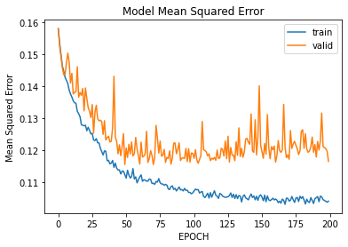

```python
#Plot for Mean Squared Error
plt.plot(hist['mse'])
plt.plot(hist['val_mse'])
plt.legend(("train" , "valid") , loc =0)
plt.title('Model Mean Squared Error')
plt.ylabel('Mean Squared Error')
plt.xlabel('EPOCH')

#This plot show overfit after the EPOCH 50, but I don't have more time to try to fix it.
```

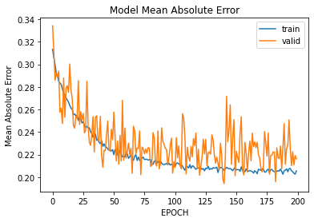

```python
#Plot for Mean Absolute Error
plt.plot(hist['mae'])
plt.plot(hist['val_mae'])
plt.legend(("train" , "valid") , loc =0)
plt.title('Model Mean Absolute Error')
plt.ylabel('Mean Absolute Error')
plt.xlabel('EPOCH')

# in this plot the Validation data seems to be erratic, i am not sure that is correct but it doesn't look as smooth as the one shwon in the hands on video.
```

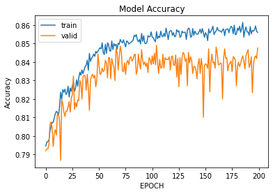

```python
#Plot for Accuracy
plt.plot(hist['accuracy'])
plt.plot(hist['val_accuracy'])
plt.legend(("train" , "valid") , loc =0)
plt.title('Model Accuracy')
plt.ylabel('Accuracy')
plt.xlabel('EPOCH')

# the maximum accuracy i got was 87 trying different hyperparameters, but it was similar to this result.
# I am not sure how to find the right combination.
```

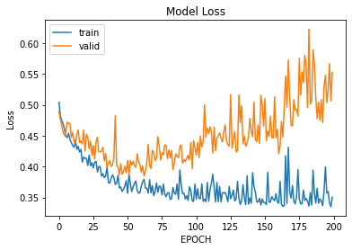

```python
#Plot for Loss
plt.plot(hist['loss'])
plt.plot(hist['val_loss'])
plt.legend(("train" , "valid") , loc =0)
plt.title('Model Loss')
plt.ylabel('Loss')
plt.xlabel('EPOCH')

# this plot is also shwoing overfit, because the validation start to increase after some point.
```

```python
from sklearn.metrics import classification_report
print(classification_report(y_test.astype('int'), y_pred.astype('int')))
```

[output not shown]

## 7. Predict the results using 0.5 as a threshold (10points)

Evaluation Keras model can be evaluated with evaluate() function

Evaluation results are contained in a list

```python
#X_test = preprocessing.normalize(X_test) # Already done in the question 5
```

```python
results = model.evaluate(X_test, y_test.values)
```

```python
print(model.metrics_names)
print(results)
```

```
['loss', 'accuracy', 'mae', 'mse']
[0.6155111789703369, 0.7919999957084656, 0.2679394781589508, 0.1750553846359253]
```

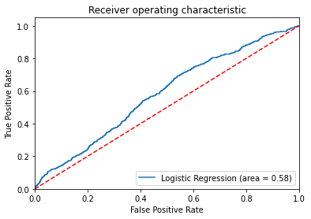

```python
from sklearn.metrics import roc_auc_score
from sklearn.metrics import roc_curve

logit_roc_auc = roc_auc_score(y_test, model.predict(X_test))
fpr, tpr, thresholds = roc_curve(y_test, model.predict_proba(X_test))
plt.figure()
plt.plot(fpr, tpr, label='Logistic Regression (area = %0.2f)' % logit_roc_auc)
plt.plot([0, 1], [0, 1],'r--')
plt.xlim([0.0, 1.0])
plt.ylim([0.0, 1.05])
plt.xlabel('False Positive Rate')
plt.ylabel('True Positive Rate')
plt.title('Receiver operating characteristic')
plt.legend(loc="lower right")
plt.savefig('Log_ROC')
plt.show()
```

## 8. Print the Accuracy score and confusion matrix (5 points)

```python
Y_pred_cls = model.predict_classes(X_test, batch_size=100, verbose=0)
print()
print('The Accuracy of the Model1 (Dropout): '+ str(model.evaluate(X_test,y_test.values)[1]))
print()
print('Recall_score: ' + str(recall_score(y_test.values,Y_pred_cls)))
print()
print('Precision_score: ' + str(precision_score(y_test.values, Y_pred_cls)))
print()
print('F-score: ' + str(f1_score(y_test.values,Y_pred_cls)))
print()
print("Roc Auc Score =",roc_auc_score(y_test,Y_pred_cls))
confusion_matrix(y_test.values, Y_pred_cls)
```

```
The Accuracy of the Model1 (Dropout): 0.7919999957084656

Recall_score: 0.05289256198347107

Precision_score: 0.3855421686746988

F-score: 0.09302325581395349

Roc Auc Score = 0.515799099363343
```

```
array([[2344,   51],
       [ 573,   32]])
```

```python
# Confusion matrix
cm = pd.DataFrame(confusion_matrix(y_test.values, Y_pred_cls))
cm.index=['Observed_0','Observed_1']
cm.columns=['Predicted_0', 'Predicted_1']
cm
#NO =0 and YES = 1
```

|  | Predicted_0 | Predicted_1 |
| --- | --- | --- |
| Observed_0 | 2344 | 51 |
| Observed_1 | 573 | 32 |

```
Confusion Matrix
```

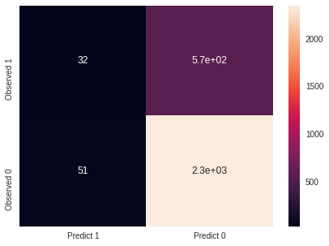

```python
#another way of looking at the Matrix
cm2=confusion_matrix(y_test.values, Y_pred_cls, labels=[1, 0])
#cm=metrics.confusion_matrix(y_test, y_predict, labels=[1, 0])

df_cm = pd.DataFrame(cm2, index = [i for i in ["Observed 1","Observed 0"]],
                  columns = [i for i in ["Predict 1","Predict 0"]])
plt.figure(figsize = (7,5))
sns.heatmap(df_cm, annot=True)
print('Confusion Matrix')
```

# **CONCLUSIONS**

## **For this project I tried differente ammount of hidden layers, with different nodes , batch and EPOCH but couldn't find the best combination of them. Howerver I clearly noticed the impact of changing onle 1 hyperparameter. Therfore we can say the result is sensitive to those minor changes of model's parameters. Hence, I believe that there should be a effective method to find the best combination.**